# Cascade of Care CUD

Luis Segura

2026-06-01

First, create the survey design object. I am also recoding some variables. Note that I am combining four binary variables to create the variable for healthcare utilization `hlth_util`. These variables are:

- `NMERTMT2` asks: During the past 12 months, that is since DATEFILL, how many different times have you been treated in an emergency room for any reason?
- `INHOSPYR` asks: During the past 12 months, have you stayed overnight or longer as an inpatient in a hospital? This is a binary no/yes variable that seems to measure hospitalization.
- `NMVSOPT2` asks: During the past 12 months, how many times have you visited a doctor, nurse, physician assistant or nurse practitioner about your own health at a doctor’s office, a clinic, or some other place?
- `TELEAPTYR2` asks: During the past 12 months, have you talked to a doctor, physician assistant, or nurse practitioner about your own health over the phone, by email, or through video calling instead of going to an in-person appointment?

We also created a combined binary variable for CUD outpatient treatment `cud_trtment` from:

- `SUTOUTMRJPY` asks: RCVD SUB USE TRMT AS AN OUTPATIENT FOR MARIJUANA USE - PY. This is a binary variable yes/no
- `SUTOUTUNSPPY` asks: RCVD SUB USE TRMT AS AN OUTPATIENT - SUB UNSPECIFIED - PY

```r
nsduh_design |>
  group_by(cud) |>
  summarise(n = n(),
            w_n = survey_total(),
            prop = survey_prop(vartype = "ci", proportion = T)) |>
  mutate(w_n = round(w_n)) |>
  mutate(across(c("prop", "prop_low", "prop_upp")) * 100)
```

| cud | n | w_n | w_n_se | prop | prop_low | prop_upp |
| --- | --- | --- | --- | --- | --- | --- |
| No CUD | 159381 | 263593715 | 3030010.6 | 93.549368 | 93.311461 | 93.779376 |
| Yes CUD | 14427 | 18175923 | 388243.4 | 6.450632 | 6.220624 | 6.688539 |

In our sample (NSDUH 2021-2023), 6.45% (6.22 - 6.69) of the US population 12 and older had cannabis use disorder, which represent 18,175,923 individuals.

## Creating the Steps of the Cascade of Care

**STEP 1:** Defining the denominator–those with CUD (n = 14,427)

```r
step_1 <- cud_design |>
  group_by(cud) |>
  summarise(n = n(),
            prop = survey_prop(vartype = "ci", proportion = T), .groups = "drop") |>
  mutate(across(c("prop", "prop_low", "prop_upp")) * 100)

step_1
```

| cud | n | prop | prop_low | prop_upp |
| --- | --- | --- | --- | --- |
| Yes CUD | 14427 | 100 | 100 | 100 |

**STEP 2:** Among those 14,427 individuals (unweighted n) with CUD, what is the proportion that utilize healthcare in the past year?

```r
step_2 <- cud_design |>
  filter(!is.na(hlth_util)) |>
  group_by(cud, hlth_util) |>
  summarise(n = n(),
            prop = survey_prop(vartype = "ci", proportion = T), .groups = "drop") |>
  mutate(across(c("prop", "prop_low", "prop_upp")) * 100)

step_2
```

| cud | hlth_util | n | prop | prop_low | prop_upp |
| --- | --- | --- | --- | --- | --- |
| Yes CUD | No | 3073 | 21.97232 | 20.64009 | 23.36523 |
| Yes CUD | Yes Healthcare Utilization | 10880 | 78.02768 | 76.63477 | 79.35991 |

**STEP 3:** Using the same 14,427 individuals with CUD, how many had cannabis screening?

Note this variable had ~24% missings. For now, we are ignoring them, but we should probably address this.

```r
step_3 <- cud_design |>
  filter(!is.na(hpusedrg)) |>
  group_by(cud, hpusedrg) |>
  summarise(n = n(),
            prop = survey_prop(vartype = "ci", proportion = T), .groups = "drop") |>
  mutate(across(c("prop", "prop_low", "prop_upp")) * 100)

step_3
```

| cud | hpusedrg | n | prop | prop_low | prop_upp |
| --- | --- | --- | --- | --- | --- |
| Yes CUD | No cannabis use screening | 2944 | 27.37725 | 25.86060 | 28.94811 |
| Yes CUD | Yes cannabis use screening | 7955 | 72.62275 | 71.05189 | 74.13940 |

**STEP 4:** using the same denominator, how many receive treatment?

Note this variable had ~30% missings. For now, we are ignoring them, but we should probably address this.

```r
step_4 <- cud_design |>
  filter(!is.na(cud_trtment)) |>
  group_by(cud, cud_trtment) |>
  summarise(n = n(),
            prop = survey_prop(vartype = "ci", proportion = T), .groups = "drop") |>
  mutate(across(c("prop", "prop_low", "prop_upp")) * 100)

step_4
```

| cud | cud_trtment | n | prop | prop_low | prop_upp |
| --- | --- | --- | --- | --- | --- |
| Yes CUD | No treatment | 9418 | 91.908759 | 90.691073 | 92.979492 |
| Yes CUD | Yes treatment | 800 | 8.091241 | 7.020508 | 9.308927 |

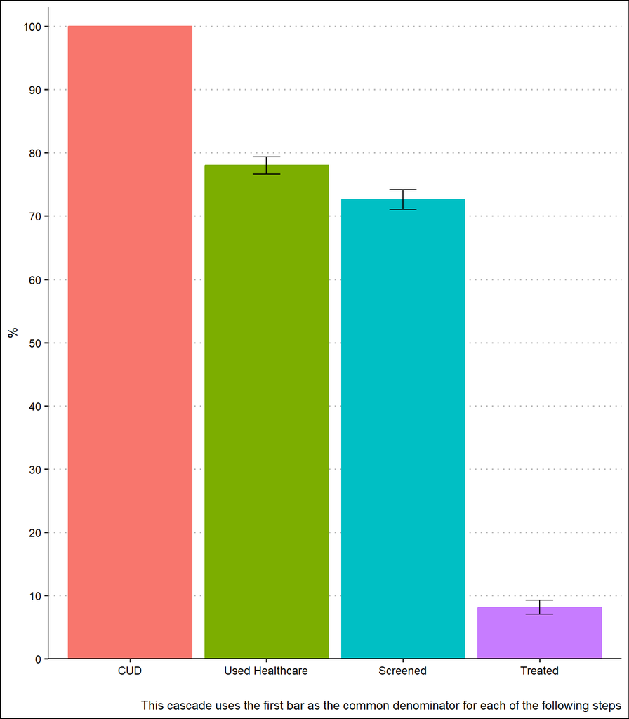

```r
### first, I need to join all the steps into one single table to create the figure.
cascade_fig <- bind_rows(
  step_1 |>
  rename(step = cud) |>
  mutate(prop_low = NA,
         prop_upp = NA),

  step_2 |>
  filter(hlth_util == "Yes Healthcare Utilization") |>
  rename(step = hlth_util) |>
  select(-cud),

  step_3 |>
  filter(hpusedrg == "Yes cannabis use screening") |>
  rename(step = hpusedrg) |>
  select(-cud),

  step_4 |>
  filter(cud_trtment  == "Yes treatment") |>
  rename(step = cud_trtment) |>
  select(-cud)
)


## changing the labels of the variable step
cascade_fig$step <- droplevels(cascade_fig$step)


cascade_fig <- cascade_fig |>
  mutate(step = fct_recode(step,
                           "CUD" = "Yes CUD",
                           "Used Healthcare" = "Yes Healthcare Utilization",
                           "Screened" = "Yes cannabis use screening",
                           "Treated" = "Yes treatment"))

## create the figure
cascade_plot <- cascade_fig |>
  ggplot(aes(x = step, y = prop,
             ymin = prop_low,
             ymax = prop_upp,
             colour = step,
             fill = step)) +
  geom_col() +
  geom_errorbar(color = "black",
                width = 0.2,
                linewidth = 0.5) +
  ggthemes::theme_clean() +
  theme(legend.position = "none") +
  labs(y = "%",
       x = "",
       caption = c("This cascade uses the first bar as the common denominator for each of the following steps")) +
  scale_y_continuous(breaks = seq(0, 100, by = 10),
                     expand = expansion(mult = c(0, 0.03)))


cascade_plot
```